# Patterns of variation in blood mercury levels in *Catharus bicknelli* and *C*. *ustulatus* on Mount Mansfield, Vermont

## Methods

We analyzed variation in blood mercury levels using mixed-effects models as implemented in R version 3.4.4 (R Core Team 2018) in the package *lme4*(Bates et al. 2015), version 1.1-15. In brief, we used a model-selection approach (Burnham and Anderson 2003) to identify the best-supported model from a candidate set of models that reflected alternative hypotheses about sources of variation in blood mercury among *Catharus* thrushes captured on Mount Mansfield, Vermont between 2000 and 2017. We used Akaike’s Information Criteria, corrected for small-sample size (AICc), as the measure of support for each model. We used the number of unique individuals included in the analysis as the sample size for the purposes of calculating AICc.

Construction of the set of candidate models was informed by previous research on mercury loads in Bicknell’s Thrush (Rimmer et al. 2005,Rimmer et al. (2010)). This work demonstrated consistent seasonal declines in mercury levels and inconsistent effects of age and sex; Rimmer et al. (2005) found that males and older individuals had higher concentrations of mercury in their blood, whereas Rimmer et al. (2010) found no effect of age or sex on blood-mercury concentration. Given the the apparent generality of the seasonal decline in concentrations of mercury on the blood, we included an effect of day-of-the-year in all models. Thus, the simplest model in our candidate set (excluding the intercept-only null model) included only an effect of sampling date. Rimmer et al. (2010) suggested that mercury levels in Bicknell’s Thrush declined more rapidly earlier in the year, so our next model included a quadratic effect of sampling date. To examine the possibility of age- and sex-related differences in blood-mercury concentrations, we added terms for sex and age (coded as hatch-year, second-year, or after-second-year) to the better-supported of the two date-only models.

We next considered a model that allowed for variation in blood-mercury concentration between Bicknell’s Thrush and Swainson’s Thrush by adding a term for species to the best-supported model. Finally, we tested for potential effects of annual variation in atmospheric deposition of mercury at our study site - previous results (Rimmer et al. 2010) suggest that individuals continue to accumulate mercury during the breeding season - by considering models that included effects of mercurcy deposition during the preceding December - June or during the preceding 1, 2, or 3 years. We included models with a range of lagged effects of mercury deposition because the rate of mercurcy cycling in montane terrestrial systems is largely unquantified.

For all of the above models, we included individual as a random effect to account for the repeated sampling of some individuals, both within and among years. We used the best-supported model to generate inference. We generated unconditional predictions from the best model and calculated confidence intervals around predictions using the bootstrap approach implemented in the ‘bootMer’ function of lme4 (Bates et al. 2015).

We analyzed temporal variation in mercury deposition using generalized additive models as implemented in the R package ‘mgcv’ version 1.8-23 (Wood 2017). We were interested in examining seasonal and annual variation, so we considered only two models, one that included terms for year and day-of-the-year, and one that included these two main effects and their intereaction, allowing for the possibility that seasonal patterns of mercury depostion have varied over time. We compared the two models using AIC, and selected for inference the model with the lower value.

## Results

### Descriptive statistics

#### Blood-mercury concentration in thrushes.

Table 1. Blood-mercury concentrations in Bicknell’s Thrush (BITH) and Swainson’s Thrush (SWTH) sampled on Mount Mansfield, Vermont 2000-2017.

| Species | Age | Sex | Mean blood mercury concentration | Standard deviation | n | Standard error | Lower 95% confidence limit | Upper 95% confidence limit |
| --- | --- | --- | --- | --- | --- | --- | --- | --- |
| BITH | ASY | Female | 0.073 | 0.027 | 39 | 0.004 | 0.064 | 0.082 |
| BITH | ASY | Male | 0.100 | 0.049 | 108 | 0.005 | 0.090 | 0.109 |
| BITH | ASY | Unknown | 0.051 | 0.030 | 4 | 0.015 | 0.003 | 0.098 |
| BITH | HY | Unknown | 0.027 | 0.015 | 41 | 0.002 | 0.023 | 0.032 |
| BITH | SY | Female | 0.068 | 0.027 | 28 | 0.005 | 0.058 | 0.078 |
| BITH | SY | Male | 0.078 | 0.032 | 79 | 0.004 | 0.071 | 0.085 |
| BITH | SY | Unknown | 0.091 | 0.017 | 3 | 0.010 | 0.049 | 0.134 |
| SWTH | ASY | Female | 0.104 | 0.028 | 7 | 0.010 | 0.078 | 0.129 |
| SWTH | ASY | Male | 0.087 | 0.020 | 22 | 0.004 | 0.079 | 0.096 |
| SWTH | ASY | Unknown | 0.077 | NA | 1 | NA | NaN | NaN |
| SWTH | SY | Female | 0.089 | 0.026 | 3 | 0.015 | 0.024 | 0.155 |
| SWTH | SY | Male | 0.085 | 0.024 | 24 | 0.005 | 0.074 | 0.095 |
| SWTH | SY | Unknown | 0.064 | NA | 1 | NA | NaN | NaN |

Table 2. Older Bicknell’s Thrush (BITH) and Swainson’s Thrush (SWTH) sampled on Mount Mansfield, Vermont between 2000 and 2017 tended to have higher blood-mercury concentrations than younger individuals.

| Species | Age | Mean blood mercury concentration | Standard deviation | n | Standard error | Lower 95% confidence limit | Upper 95% confidence limit |
| --- | --- | --- | --- | --- | --- | --- | --- |
| BITH | ASY | 0.091 | 0.046 | 151 | 0.004 | 0.084 | 0.099 |
| BITH | HY | 0.027 | 0.015 | 41 | 0.002 | 0.023 | 0.032 |
| BITH | SY | 0.076 | 0.031 | 110 | 0.003 | 0.070 | 0.082 |
| SWTH | ASY | 0.091 | 0.022 | 30 | 0.004 | 0.083 | 0.099 |
| SWTH | SY | 0.084 | 0.024 | 28 | 0.004 | 0.075 | 0.094 |

Table 3. Male Bicknell’s Thrush (BITH) sampled on Mount Mansfield, Vermont between 2000 and 2017 tended to have higher blood-mercury concentrations than females. Male and female Swainson’s Thrush (SWTH) did not differ appreciably in blood-mercury concentration.

| Species | Sex | Mean blood mercury concentration | Standard deviation | n | Standard error | Lower 95% confidence limit | Upper 95% confidence limit |
| --- | --- | --- | --- | --- | --- | --- | --- |
| BITH | Female | 0.071 | 0.027 | 67 | 0.003 | 0.064 | 0.077 |
| BITH | Male | 0.091 | 0.044 | 187 | 0.003 | 0.084 | 0.097 |
| BITH | Unknown | 0.033 | 0.023 | 48 | 0.003 | 0.027 | 0.040 |
| SWTH | Female | 0.099 | 0.027 | 10 | 0.008 | 0.080 | 0.118 |
| SWTH | Male | 0.086 | 0.022 | 46 | 0.003 | 0.079 | 0.092 |
| SWTH | Unknown | 0.071 | 0.009 | 2 | 0.007 | -0.014 | 0.156 |

#### Variation in mercury deposition over time.

The model that included an interaction between year and day-of-the year (gam.m1) had a lower AIC value than did the simpler model (gam.m2) without the interaction, so we used the more complicated model for inference.

Table 4. AICc model comparison supports a generalized additive model that includes effects of day of the year, year, and their interaction.

|  | df | AIC |
| --- | --- | --- |
| gam.m1 | 31.04459 | -3011.895 |
| gam.m2 | 14.31713 | -3005.494 |

Table 5. Summary results of the best-supported generalized additive model show significant seasonal and yearly variation in mercury deposition on Mount Mansfield, Vermont.

| A. parametric coefficients | Estimate | Std. Error | t-value | p-value |
| --- | --- | --- | --- | --- |
| (Intercept) | 0.1007 | 0.0026 | 38.0973 | < 0.0001 |
| B. smooth terms | edf | Ref.df | F-value | p-value |
| Day of the year | 5.8243 | 28.0000 | 10.8155 | < 0.0001 |
| Year | 5.4880 | 6.8283 | 5.3886 | < 0.0001 |
| Day of the year * Year | 14.7229 | 182.0000 | 0.1423 | 0.0038 |

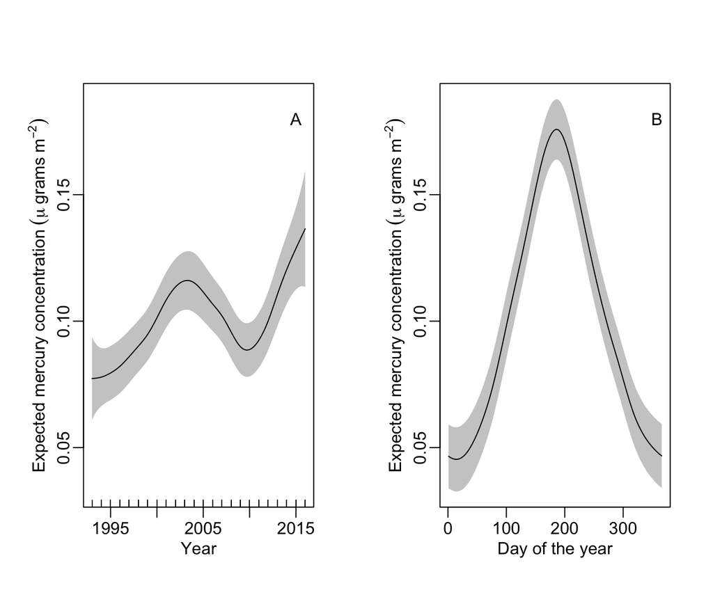

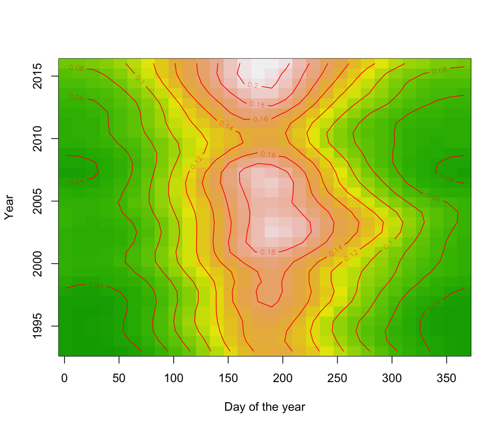

Figure 2. Periods of peak mercury deposition on Mount Mansfield, Vermont have increased from 1993 - 2017 and have become become more strongly seasonal.Whiter areas indicate periods of higher deposition; greener areas show periods of lower deposition. Red lines show the expected concentration of mercury deposition.

## Formal analysis of variation in blood-mercury concentration.

The best-supported model (i.e., with the lowest AICc) in the candidate set included an effect of sampling date, age, and sex of the individual. The data did not support an effect of species (i.e., blood-mercury concentrations are similar in Bicknell’s Thrush and Swainson’s Thrush)(delta AIC = 2.02). We found no evidence, either, for any temporal trend in blood-mercury concentration; the model with a term for “year” had only a slightly higher log-likelihood (LL). Finally, none of the models that included an effect of atmospheric deposition rate (6-month dep, 1-year dep, 2-year dep, or 3-year dep) performed substantially better than the simpler model.

Table 6. Relative support for candidate models explaining variation in blood-mercury concentration in Bicknell’s Thrush and Swainson’s Thrush on Mount Mansfield, Vermont.

|  | Model | No. parameters | AICc | Delta AICc | Model likelihood | AICc weight | Log likelihood | Cumulative model weight |
| --- | --- | --- | --- | --- | --- | --- | --- | --- |
| 4 | Date+age+sex | 9 | -1464.814 | 0.0000000 | 1.0000000 | 0.2812050 | 741.8068 | 0.2812050 |
| 6 | Date+age+sex+year | 10 | -1464.116 | 0.6974992 | 0.7055698 | 0.1984097 | 742.5491 | 0.4796147 |
| 7 | Date+age+sex+6-month dep | 10 | -1463.022 | 1.7913796 | 0.4083258 | 0.1148233 | 742.0022 | 0.5944380 |
| 9 | Date+age+sex+2-year dep | 10 | -1462.947 | 1.8663550 | 0.3933020 | 0.1105985 | 741.9647 | 0.7050365 |
| 5 | Date+age+sex+species | 10 | -1462.792 | 2.0213094 | 0.3639806 | 0.1023532 | 741.8872 | 0.8073896 |
| 10 | Date+age+sex+3-year dep | 10 | -1462.705 | 2.1081050 | 0.3485225 | 0.0980063 | 741.8438 | 0.9053959 |
| 8 | Date+age+sex+1-year dep | 10 | -1462.635 | 2.1787901 | 0.3364200 | 0.0946030 | 741.8085 | 0.9999989 |
| 3 | Quadratic date | 5 | -1439.760 | 25.0531039 | 0.0000036 | 0.0000010 | 725.0112 | 0.9999999 |
| 2 | Date | 4 | -1435.573 | 29.2408052 | 0.0000004 | 0.0000001 | 721.8733 | 1.0000000 |
| 1 | Null | 3 | -1301.995 | 162.8187284 | 0.0000000 | 0.0000000 | 654.0494 | 1.0000000 |

**Note:**  
Date refers to day of the year on which the blood sample was drawn. Age is the age of the bird: hatch-year, second-year, or after-second-year. Sex is male, female, or unknown. 6-month dep is the average mercury deposition at the Underhill station during the December - June preceding the blood sample. 1-, 2-, and 3-year dep, respectively, is the average mercury deposition at the Underhill station during the previous 1, 2, or 3 years (June - June).

Examining the output of the best-supported model (‘Date+age+sex’), we see that date has the strongest correlation with blood-mercury concentration; the effects of age and sex are substantially weaker.

|  | Sum Sq | Mean Sq | NumDF | DenDF | F.value | Pr(>F) |
| --- | --- | --- | --- | --- | --- | --- |
| jdate | 0.0089 | 0.0089 | 1 | 301.8602 | 15.0890 | 0.0001 |
| I(jdate^2) | 0.0050 | 0.0050 | 1 | 313.8066 | 8.3771 | 0.0041 |
| ageCat | 0.0038 | 0.0019 | 2 | 354.9590 | 3.2227 | 0.0410 |
| sexCat | 0.0035 | 0.0017 | 2 | 261.2502 | 2.9588 | 0.0536 |

**Note:**  
‘jdate’ refers to day of the year on which the blood sample was drawn. I(date^2) is the quadratic effect of day of the year. ‘ageCat’ is the age of the bird: hatch-year, second-year, or after-second-year. ‘sexCat’ is male, female, or unknown.

Overall, the fixed-effects in the model (date, age, and sex; R2m) explain ~38% of the variation in blood-mercury levels. The fixed- and random-effects together (R2c) explain ~65% of the variation. This suggests substantial amounts of individual variation in blood-mercury concentration that are not explained by any of the factors considered in this analysis. This could be due to individual differences in ability to offload mercury or individual differences in exposure at any point during their life cycle.

|  | R-squared |
| --- | --- |
| R2m | 0.3784482 |
| R2c | 0.6498770 |

As indicated by the model results, males tend to have higher mercury levels than females, and older birds tend to have higher mercury levels than younger birds. However, broad overlap exists among all demographic groups (Figs. 3, 4).

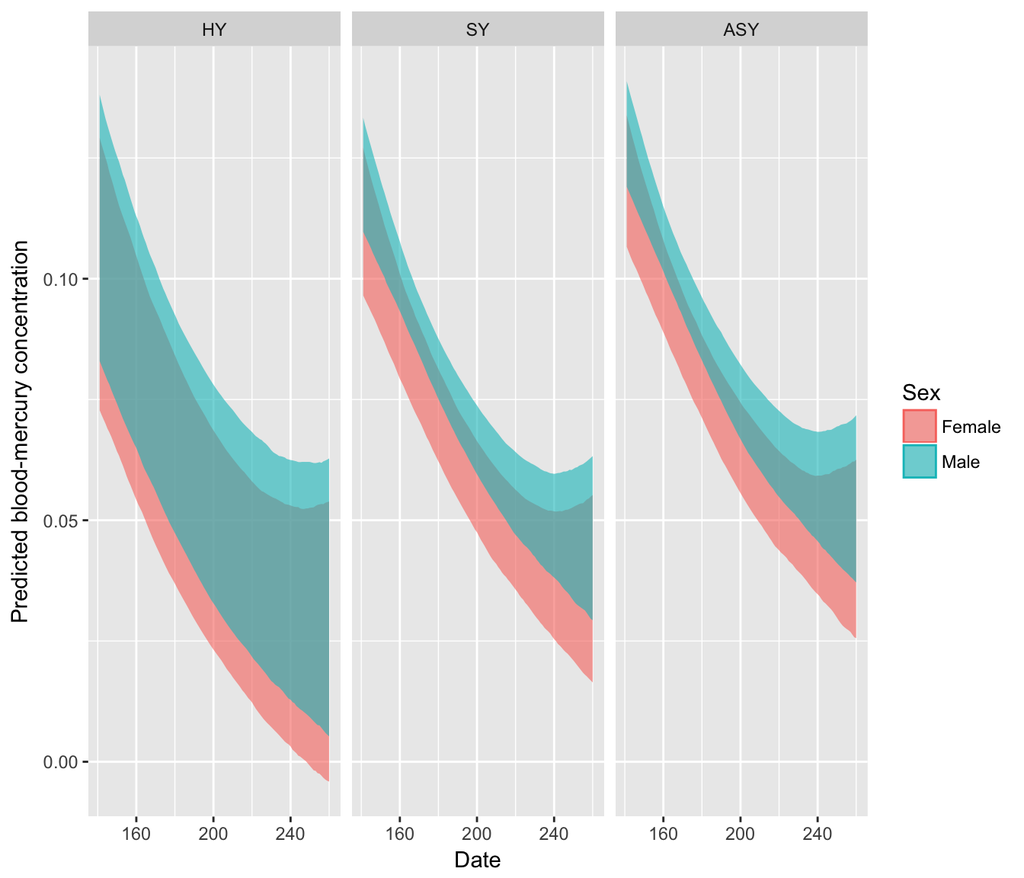

Figure 3. Male Bicknell’s Thrush and Swainson’s Thrush tended to have higher predicted concentrations of mercury in the blood than did females. However, 95% confidence intervals (the red and blue filled areas) overlapped extensively. Lighter blue portions of the figure show concentrations predicted only for males, darker blue portions show concentrations predicted for both sexes, and red-shaded areas show predicted concentrations expected only for females. Panels show, respectively, predicted values for hatch-year (HY), second-year (SY), and after-second-year (ASY) individuals.

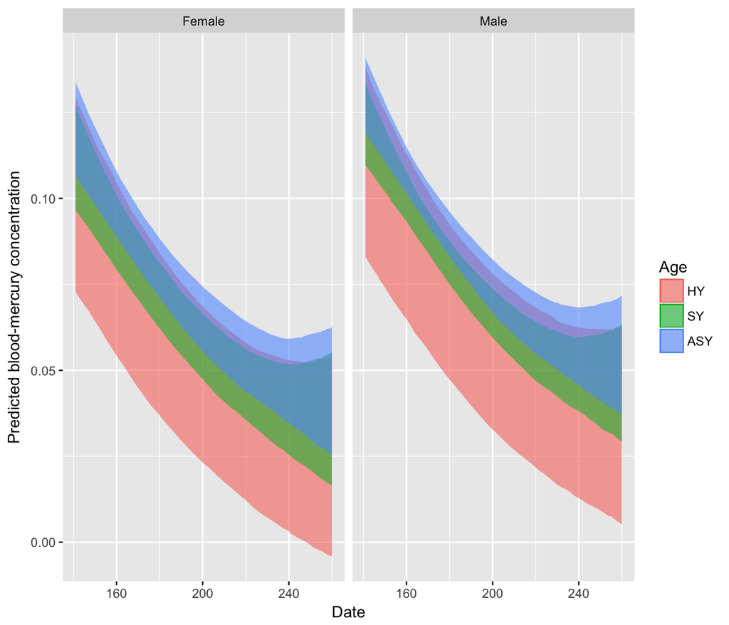

Figure 4. Older Bicknell’s Thrush and Swainson’s Thrush tended to have higher predicted concentrations of mercury in the blood than did younger birds. However, 95% confidence intervals overlapped extensively. Purple portions of the figure show concentrations predicted only for ASY individuals, light blue portions show concentrations predicted for ASY and SY individuals, dark blue areas show concentrations expected of birds of any age, light green portions show concentrations expected for SY individuals, olive portions show concentrations expected for SY and HY individuals, and red-shaded areas show predicted concentrations expected only for HY individuals. Panels show, respectively, predicted values for females and males.

## References

Bates D, Mächler M, Bolker B, Walker S (2015) Fitting linear mixed-effects models using lme4. Journal of Statistical Software 67:1–48. doi: 10.18637/jss.v067.i01

Burnham KP, Anderson DR (2003) Model selection and multimodel inference: A practical information-theoretic approach. Springer Science & Business Media

R Core Team (2018) R: A language and environment for statistical computing. R Foundation for Statistical Computing, Vienna, Austria

Rimmer CC, McFarland KP, Evers DC et al (2005) Mercury concentrations in bicknell’s thrush and other insectivorous passerines in montane forests of northeastern north america. Ecotoxicology 14:223–240

Rimmer CC, Miller EK, McFarland KP et al (2010) Mercury bioaccumulation and trophic transfer in the terrestrial food web of a montane forest. Ecotoxicology 19:697–709

Wood SN (2017) Generalized additive models: An introduction with r. CRC press